# Red Wine EDA by Alaa Zarban

```r
#head(red_wine)
lengths(red_wine)
```

```
##                    X        fixed.acidity     volatile.acidity
##                 1599                 1599                 1599
##          citric.acid       residual.sugar            chlorides
##                 1599                 1599                 1599
##  free.sulfur.dioxide total.sulfur.dioxide              density
##                 1599                 1599                 1599
##                   pH            sulphates              alcohol
##                 1599                 1599                 1599
##              quality
##                 1599
```

### What is the structure of your dataset?

The provided data set consist of mutiple records of red wine and its charastrastics. The data set consist of 13 columns and 1599 records of wine. Each record provide the different feature and aspect of each record of wine.

# Univariate Plots Section

```
##        X          fixed.acidity   volatile.acidity  citric.acid
##  Min.   :   1.0   Min.   : 4.60   Min.   :0.1200   Min.   :0.000
##  1st Qu.: 400.5   1st Qu.: 7.10   1st Qu.:0.3900   1st Qu.:0.090
##  Median : 800.0   Median : 7.90   Median :0.5200   Median :0.260
##  Mean   : 800.0   Mean   : 8.32   Mean   :0.5278   Mean   :0.271
##  3rd Qu.:1199.5   3rd Qu.: 9.20   3rd Qu.:0.6400   3rd Qu.:0.420
##  Max.   :1599.0   Max.   :15.90   Max.   :1.5800   Max.   :1.000
##  residual.sugar     chlorides       free.sulfur.dioxide
##  Min.   : 0.900   Min.   :0.01200   Min.   : 1.00
##  1st Qu.: 1.900   1st Qu.:0.07000   1st Qu.: 7.00
##  Median : 2.200   Median :0.07900   Median :14.00
##  Mean   : 2.539   Mean   :0.08747   Mean   :15.87
##  3rd Qu.: 2.600   3rd Qu.:0.09000   3rd Qu.:21.00
##  Max.   :15.500   Max.   :0.61100   Max.   :72.00
##  total.sulfur.dioxide    density             pH          sulphates
##  Min.   :  6.00       Min.   :0.9901   Min.   :2.740   Min.   :0.3300
##  1st Qu.: 22.00       1st Qu.:0.9956   1st Qu.:3.210   1st Qu.:0.5500
##  Median : 38.00       Median :0.9968   Median :3.310   Median :0.6200
##  Mean   : 46.47       Mean   :0.9967   Mean   :3.311   Mean   :0.6581
##  3rd Qu.: 62.00       3rd Qu.:0.9978   3rd Qu.:3.400   3rd Qu.:0.7300
##  Max.   :289.00       Max.   :1.0037   Max.   :4.010   Max.   :2.0000
##     alcohol         quality
##  Min.   : 8.40   Min.   :3.000
##  1st Qu.: 9.50   1st Qu.:5.000
##  Median :10.20   Median :6.000
##  Mean   :10.42   Mean   :5.636
##  3rd Qu.:11.10   3rd Qu.:6.000
##  Max.   :14.90   Max.   :8.000
```

From the above summary, we can see that the quality of the wine varies from 3 to 8. The mean of all red wine records is 5.6 and the median is 6.

I am curious to know what feature/charactrastic of the provided in the data set indicate a high quality red wine and the vise versa. Let dive deep into the data and find-out.

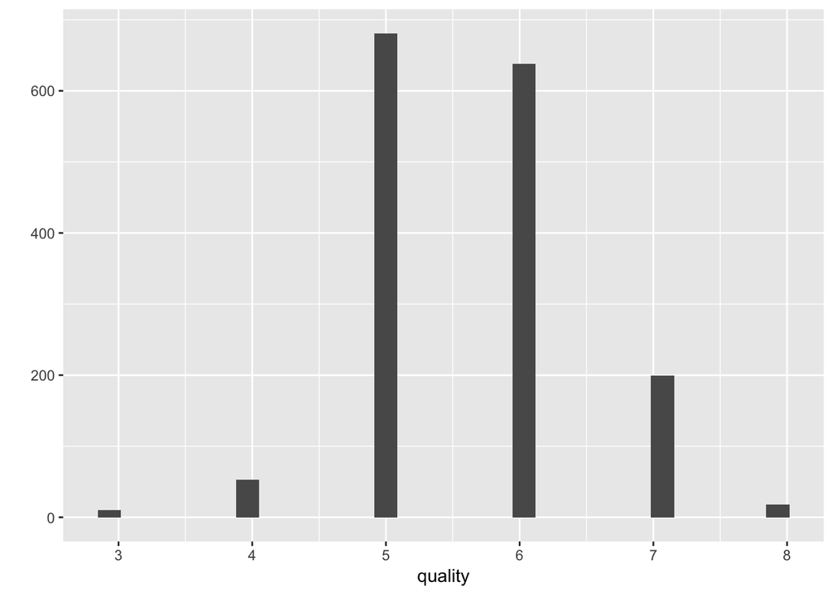

```r
qplot(x=quality , data = red_wine)
```

# Univariate Analysis

### What is/are the main feature(s) of interest in your dataset?

The red wine dataset consists of 13 column. eleven column are the features/characteristics of red wine that might affect the quality.

### Did you create any new variables from existing variables in the dataset?

yes. quality categories.

### Of the features you investigated, were there any unusual distributions? Did you perform any operations on the data to tidy, adjust, or change the form of the data? If so, why did you do this?

**Concern** Do I have to check the histogram of each column whether it is normally distributed. If not, why do i have to transform it?

# Bivariate Plots Section

From the graphs above, we can see that most of the red wine score 5 and 6 in the quality, very few are having low quality and high quality as well.

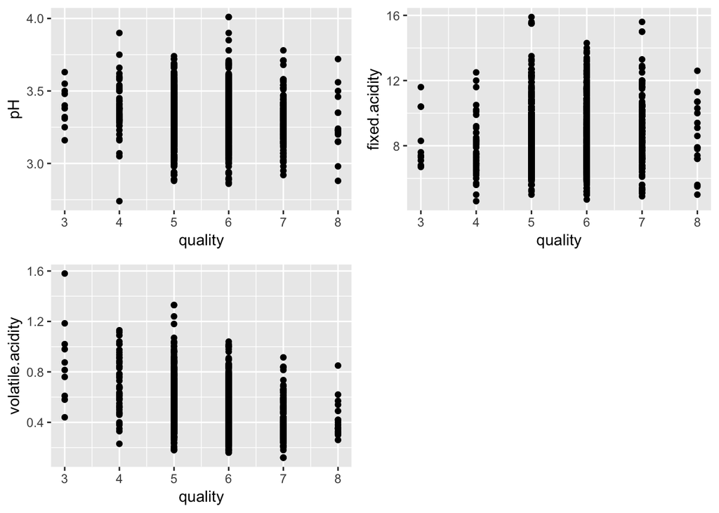

```r
r1 <- qplot(x = quality , y = pH , data = red_wine)
r2 <- qplot(x = quality , y = fixed.acidity , data = red_wine)
r3 <- qplot(x = quality , y = volatile.acidity , data = red_wine)
r4 <- qplot(x = quality , y = citric.acid , data = red_wine)
r5 <- qplot(x = quality , y = residual.sugar , data = red_wine)
r6 <- qplot(x = quality , y = chlorides , data = red_wine)
r7 <- qplot(x = quality , y = free.sulfur.dioxide , data = red_wine)
r8 <- qplot(x = quality , y = total.sulfur.dioxide , data = red_wine)
r9 <- qplot(x = quality , y = density , data = red_wine)
r10 <- qplot(x = quality , y = sulphates , data = red_wine)
r11 <- qplot(x = quality , y = alcohol , data = red_wine)

grid.arrange(r1,r2 ,r3, ncol=2)
```

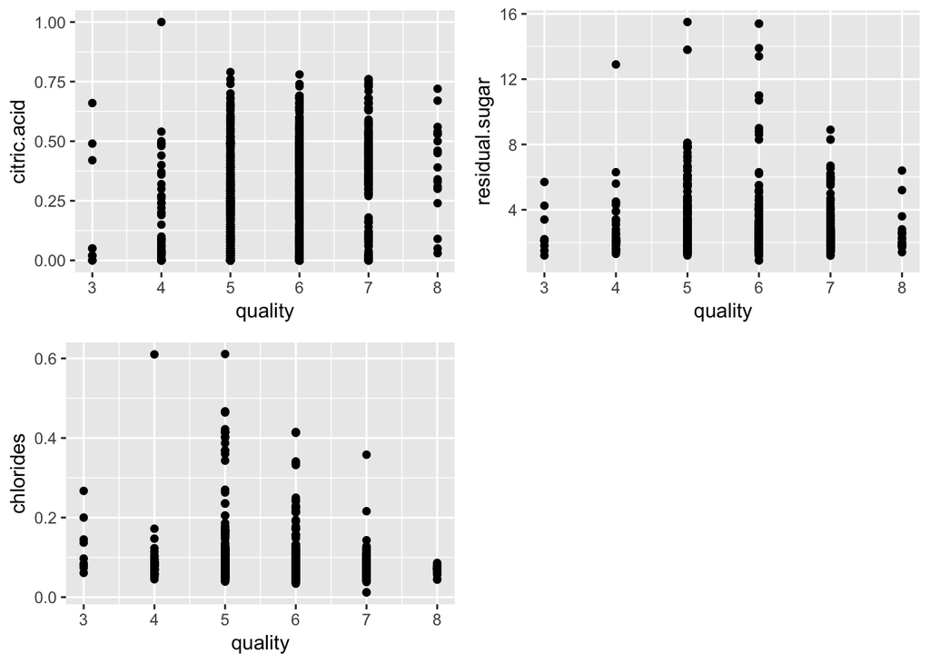

```r
grid.arrange(r4,r5,r6, ncol=2)
```

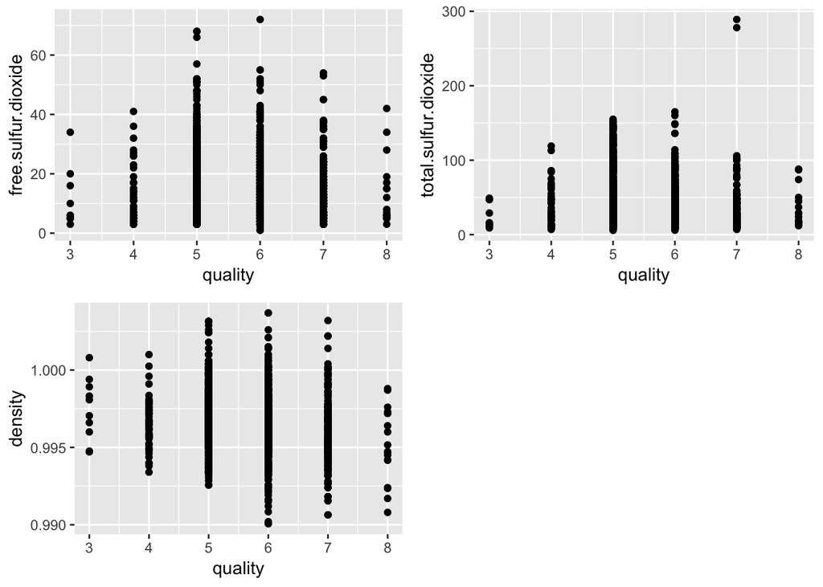

```r
grid.arrange(r7,r8,r9, ncol=2)
```

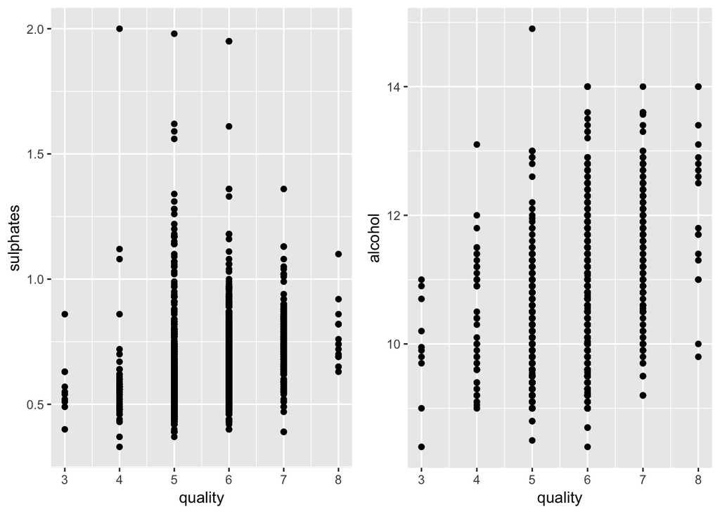

```r
grid.arrange(r10,r11, ncol=2)
```

Scatter plot is not the suitable graph to show clear relation between quality and other charastristics. Let’s use another type.

```r
red_wine$quality.factor <- factor(red_wine$quality)
red_wine$quality.category <- NA
red_wine$quality.category <- ifelse(red_wine$quality>=7, 'good', NA)
red_wine$quality.category <- ifelse(red_wine$quality==5, 'medium', red_wine$quality.category)
red_wine$quality.category <- ifelse(red_wine$quality==6, 'medium', red_wine$quality.category)
red_wine$quality.category <- ifelse(red_wine$quality<=4, 'bad', red_wine$quality.category)

red_wine$quality.category <- factor(red_wine$quality.category, levels = c("bad", "medium", "good"))

head(red_wine)
```

```
##   X fixed.acidity volatile.acidity citric.acid residual.sugar chlorides
## 1 1           7.4             0.70        0.00            1.9     0.076
## 2 2           7.8             0.88        0.00            2.6     0.098
## 3 3           7.8             0.76        0.04            2.3     0.092
## 4 4          11.2             0.28        0.56            1.9     0.075
## 5 5           7.4             0.70        0.00            1.9     0.076
## 6 6           7.4             0.66        0.00            1.8     0.075
##   free.sulfur.dioxide total.sulfur.dioxide density   pH sulphates alcohol
## 1                  11                   34  0.9978 3.51      0.56     9.4
## 2                  25                   67  0.9968 3.20      0.68     9.8
## 3                  15                   54  0.9970 3.26      0.65     9.8
## 4                  17                   60  0.9980 3.16      0.58     9.8
## 5                  11                   34  0.9978 3.51      0.56     9.4
## 6                  13                   40  0.9978 3.51      0.56     9.4
##   quality quality.factor quality.category
## 1       5              5           medium
## 2       5              5           medium
## 3       5              5           medium
## 4       6              6           medium
## 5       5              5           medium
## 6       5              5           medium
```

Now, we can create our boxplot graph with the different categories created for the quality.

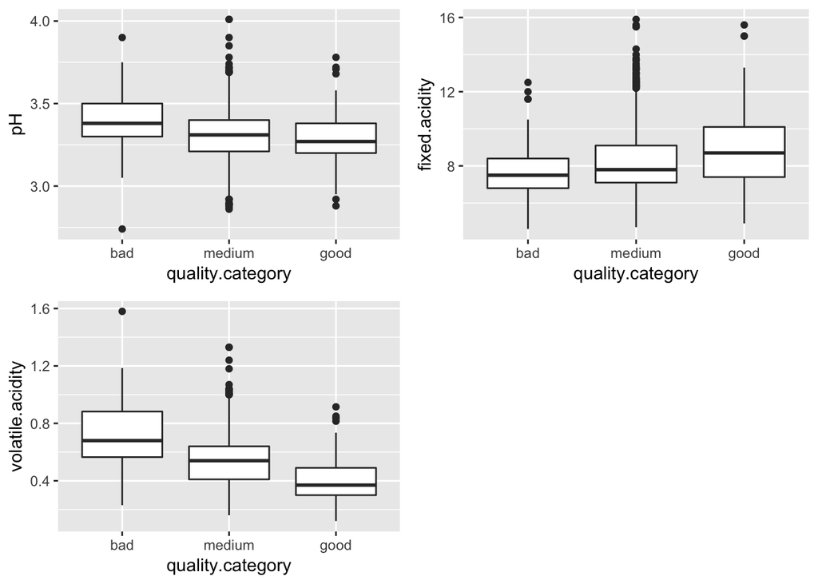

```r
r1 <- qplot(x = quality.category , y = pH , data = red_wine , geom = 'boxplot')
r2 <- qplot(x = quality.category , y = fixed.acidity , data = red_wine, geom = 'boxplot')
r3 <- qplot(x = quality.category , y = volatile.acidity , data = red_wine, geom = 'boxplot')
r4 <- qplot(x = quality.category , y = citric.acid , data = red_wine, geom = 'boxplot')
r5 <- qplot(x = quality.category , y = residual.sugar , data = red_wine, geom = 'boxplot')
r6 <- qplot(x = quality.category , y = chlorides , data = red_wine, geom = 'boxplot')
r7 <- qplot(x = quality.category , y = free.sulfur.dioxide , data = red_wine, geom = 'boxplot')
r8 <- qplot(x = quality.category , y = total.sulfur.dioxide , data = red_wine, geom = 'boxplot')
r9 <- qplot(x = quality.category , y = density , data = red_wine, geom = 'boxplot')
r10 <- qplot(x = quality.category , y = sulphates , data = red_wine, geom = 'boxplot')
r11 <- qplot(x = quality.category , y = alcohol , data = red_wine, geom = 'boxplot')

grid.arrange(r1,r2 ,r3, ncol=2)
```

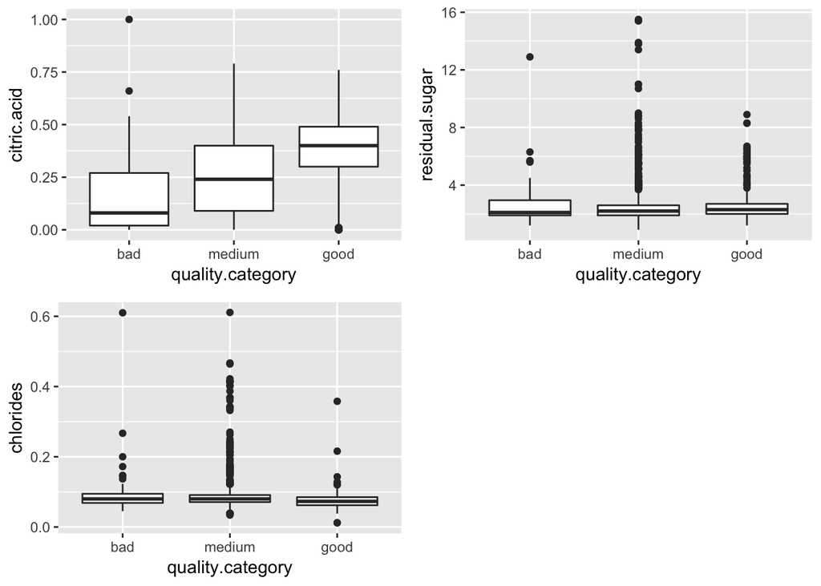

```r
grid.arrange(r4,r5,r6, ncol=2)
```

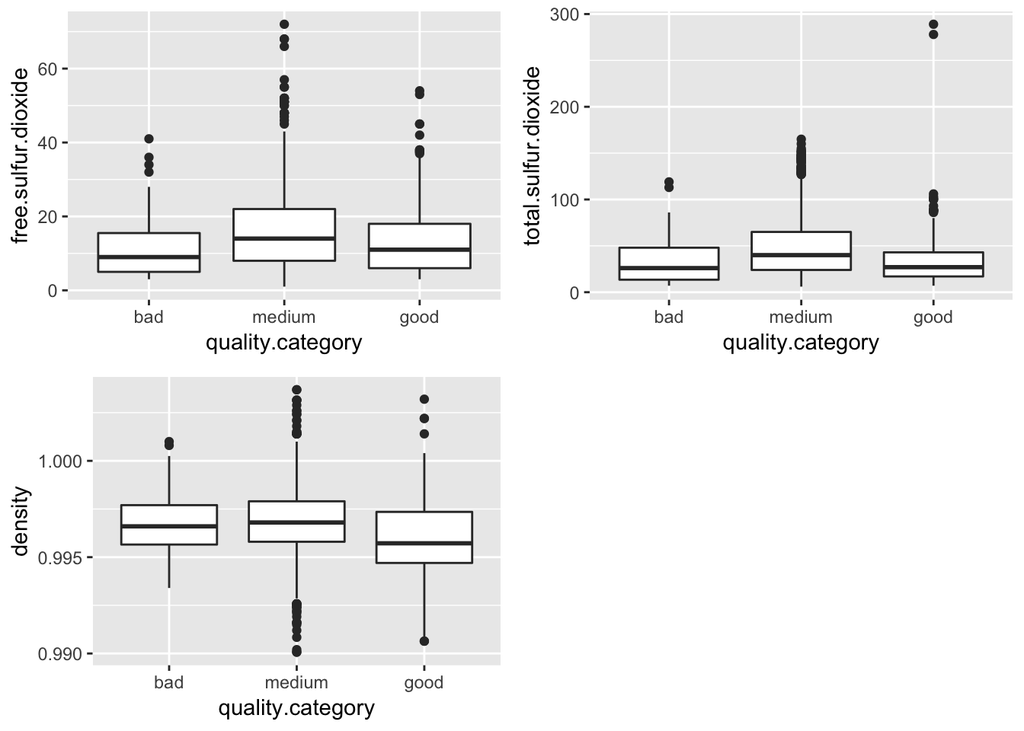

```r
grid.arrange(r7,r8,r9, ncol=2)
```

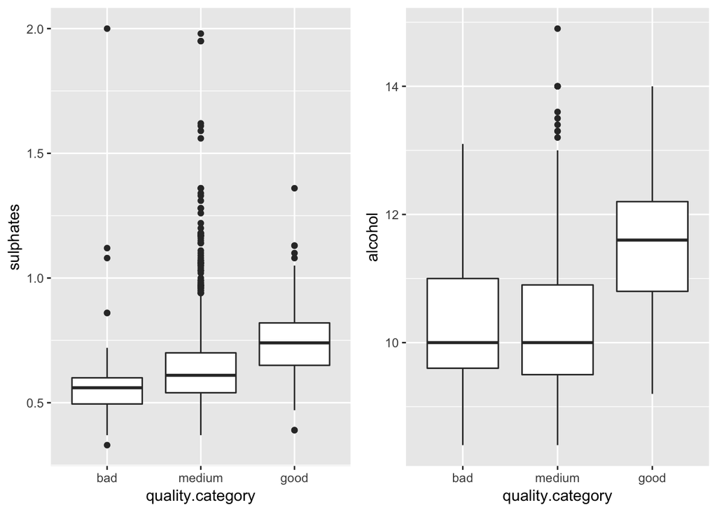

```r
grid.arrange(r10,r11, ncol=2)
```

From the boxplots graph above we can summarize our findings as follows: - As pH increases, the quality decreases. - As volatile.acidity increases, the quality decreases. - As fixed.acidity increases, the quality increases. - As citric.acid increases, the quality increases. - As sulphates increases, the quality increases.

From the below correlation test, no strong relation ( > 0.7 ) found between variables in the dataset.

```r
cor(red_wine[,2:13]) > 0.7
```

```
##                      fixed.acidity volatile.acidity citric.acid
## fixed.acidity                 TRUE            FALSE       FALSE
## volatile.acidity             FALSE             TRUE       FALSE
## citric.acid                  FALSE            FALSE        TRUE
## residual.sugar               FALSE            FALSE       FALSE
## chlorides                    FALSE            FALSE       FALSE
## free.sulfur.dioxide          FALSE            FALSE       FALSE
## total.sulfur.dioxide         FALSE            FALSE       FALSE
## density                      FALSE            FALSE       FALSE
## pH                           FALSE            FALSE       FALSE
## sulphates                    FALSE            FALSE       FALSE
## alcohol                      FALSE            FALSE       FALSE
## quality                      FALSE            FALSE       FALSE
##                      residual.sugar chlorides free.sulfur.dioxide
## fixed.acidity                 FALSE     FALSE               FALSE
## volatile.acidity              FALSE     FALSE               FALSE
## citric.acid                   FALSE     FALSE               FALSE
## residual.sugar                 TRUE     FALSE               FALSE
## chlorides                     FALSE      TRUE               FALSE
## free.sulfur.dioxide           FALSE     FALSE                TRUE
## total.sulfur.dioxide          FALSE     FALSE               FALSE
## density                       FALSE     FALSE               FALSE
## pH                            FALSE     FALSE               FALSE
## sulphates                     FALSE     FALSE               FALSE
## alcohol                       FALSE     FALSE               FALSE
## quality                       FALSE     FALSE               FALSE
##                      total.sulfur.dioxide density    pH sulphates alcohol
## fixed.acidity                       FALSE   FALSE FALSE     FALSE   FALSE
## volatile.acidity                    FALSE   FALSE FALSE     FALSE   FALSE
## citric.acid                         FALSE   FALSE FALSE     FALSE   FALSE
## residual.sugar                      FALSE   FALSE FALSE     FALSE   FALSE
## chlorides                           FALSE   FALSE FALSE     FALSE   FALSE
## free.sulfur.dioxide                 FALSE   FALSE FALSE     FALSE   FALSE
## total.sulfur.dioxide                 TRUE   FALSE FALSE     FALSE   FALSE
## density                             FALSE    TRUE FALSE     FALSE   FALSE
## pH                                  FALSE   FALSE  TRUE     FALSE   FALSE
## sulphates                           FALSE   FALSE FALSE      TRUE   FALSE
## alcohol                             FALSE   FALSE FALSE     FALSE    TRUE
## quality                             FALSE   FALSE FALSE     FALSE   FALSE
##                      quality
## fixed.acidity          FALSE
## volatile.acidity       FALSE
## citric.acid            FALSE
## residual.sugar         FALSE
## chlorides              FALSE
## free.sulfur.dioxide    FALSE
## total.sulfur.dioxide   FALSE
## density                FALSE
## pH                     FALSE
## sulphates              FALSE
## alcohol                FALSE
## quality                 TRUE
```

From the below correlation test, we have couple of moderate relations ( > 0.5 ) found between variables in the dataset, summarized as follows:

citric.acid <> fixed.acidity density <> fixed.acidity fixed.acidity <> citric.acid total.sulfur.dioxide <> free.sulfur.dioxide

```r
cor(red_wine[,2:13]) > 0.5
```

```
##                      fixed.acidity volatile.acidity citric.acid
## fixed.acidity                 TRUE            FALSE        TRUE
## volatile.acidity             FALSE             TRUE       FALSE
## citric.acid                   TRUE            FALSE        TRUE
## residual.sugar               FALSE            FALSE       FALSE
## chlorides                    FALSE            FALSE       FALSE
## free.sulfur.dioxide          FALSE            FALSE       FALSE
## total.sulfur.dioxide         FALSE            FALSE       FALSE
## density                       TRUE            FALSE       FALSE
## pH                           FALSE            FALSE       FALSE
## sulphates                    FALSE            FALSE       FALSE
## alcohol                      FALSE            FALSE       FALSE
## quality                      FALSE            FALSE       FALSE
##                      residual.sugar chlorides free.sulfur.dioxide
## fixed.acidity                 FALSE     FALSE               FALSE
## volatile.acidity              FALSE     FALSE               FALSE
## citric.acid                   FALSE     FALSE               FALSE
## residual.sugar                 TRUE     FALSE               FALSE
## chlorides                     FALSE      TRUE               FALSE
## free.sulfur.dioxide           FALSE     FALSE                TRUE
## total.sulfur.dioxide          FALSE     FALSE                TRUE
## density                       FALSE     FALSE               FALSE
## pH                            FALSE     FALSE               FALSE
## sulphates                     FALSE     FALSE               FALSE
## alcohol                       FALSE     FALSE               FALSE
## quality                       FALSE     FALSE               FALSE
##                      total.sulfur.dioxide density    pH sulphates alcohol
## fixed.acidity                       FALSE    TRUE FALSE     FALSE   FALSE
## volatile.acidity                    FALSE   FALSE FALSE     FALSE   FALSE
## citric.acid                         FALSE   FALSE FALSE     FALSE   FALSE
## residual.sugar                      FALSE   FALSE FALSE     FALSE   FALSE
## chlorides                           FALSE   FALSE FALSE     FALSE   FALSE
## free.sulfur.dioxide                  TRUE   FALSE FALSE     FALSE   FALSE
## total.sulfur.dioxide                 TRUE   FALSE FALSE     FALSE   FALSE
## density                             FALSE    TRUE FALSE     FALSE   FALSE
## pH                                  FALSE   FALSE  TRUE     FALSE   FALSE
## sulphates                           FALSE   FALSE FALSE      TRUE   FALSE
## alcohol                             FALSE   FALSE FALSE     FALSE    TRUE
## quality                             FALSE   FALSE FALSE     FALSE   FALSE
##                      quality
## fixed.acidity          FALSE
## volatile.acidity       FALSE
## citric.acid            FALSE
## residual.sugar         FALSE
## chlorides              FALSE
## free.sulfur.dioxide    FALSE
## total.sulfur.dioxide   FALSE
## density                FALSE
## pH                     FALSE
## sulphates              FALSE
## alcohol                FALSE
## quality                 TRUE
```

# Bivariate Analysis

### Talk about some of the relationships you observed in this part of the investigation. How did the feature(s) of interest vary with other features in the dataset?

This has been answered above.

### Did you observe any interesting relationships between the other features (not the main feature(s) of interest)?

This is answered in the correlation section above.

### What was the strongest relationship you found?

From below code, the strongest relation is: fixed.acidity <> pH = -0.68 fixed.acidity <> citric.acid = 0.67

```r
# The following piece of code has been taken from:
#  http://www.sthda.com/english/wiki/correlation-matrix-a-quick-start-guide-to-analyze-format-and-visualize-a-correlation-matrix-using-r-software

# ++++++++++++++++++++++++++++
# flattenCorrMatrix
# ++++++++++++++++++++++++++++
# cormat : matrix of the correlation coefficients
# pmat : matrix of the correlation p-values
flattenCorrMatrix <- function(cormat, pmat) {
  ut <- upper.tri(cormat)
  data.frame(
    row = rownames(cormat)[row(cormat)[ut]],
    column = rownames(cormat)[col(cormat)[ut]],
    cor  =(cormat)[ut],
    p = pmat[ut]
    )
}

library(Hmisc)
check <- rcorr(as.matrix(red_wine[,2:13]))
check_faltten <- flattenCorrMatrix(check$r, check$P)
sorted_data <- check_faltten[order(check_faltten$cor),]
sorted_data
```

```
##                     row               column          cor            p
## 29        fixed.acidity                   pH -0.682978195 0.000000e+00
## 3      volatile.acidity          citric.acid -0.552495685 0.000000e+00
## 31          citric.acid                   pH -0.541904145 0.000000e+00
## 53              density              alcohol -0.496179770 0.000000e+00
## 57     volatile.acidity              quality -0.390557780 0.000000e+00
## 36              density                   pH -0.341699335 0.000000e+00
## 33            chlorides                   pH -0.265026131 0.000000e+00
## 38     volatile.acidity            sulphates -0.260986685 0.000000e+00
## 1         fixed.acidity     volatile.acidity -0.256130895 0.000000e+00
## 50            chlorides              alcohol -0.221140545 0.000000e+00
## 52 total.sulfur.dioxide              alcohol -0.205653944 0.000000e+00
## 47     volatile.acidity              alcohol -0.202288027 4.440892e-16
## 45                   pH            sulphates -0.196647602 2.220446e-15
## 62 total.sulfur.dioxide              quality -0.185100289 8.615331e-14
```

[output cut: 52 more lines]

# Multivariate Plots Section

From above analysis, the top charactrastics that affects quality are

Negativly: volatile.acidity

Postivly alcohol sulphates

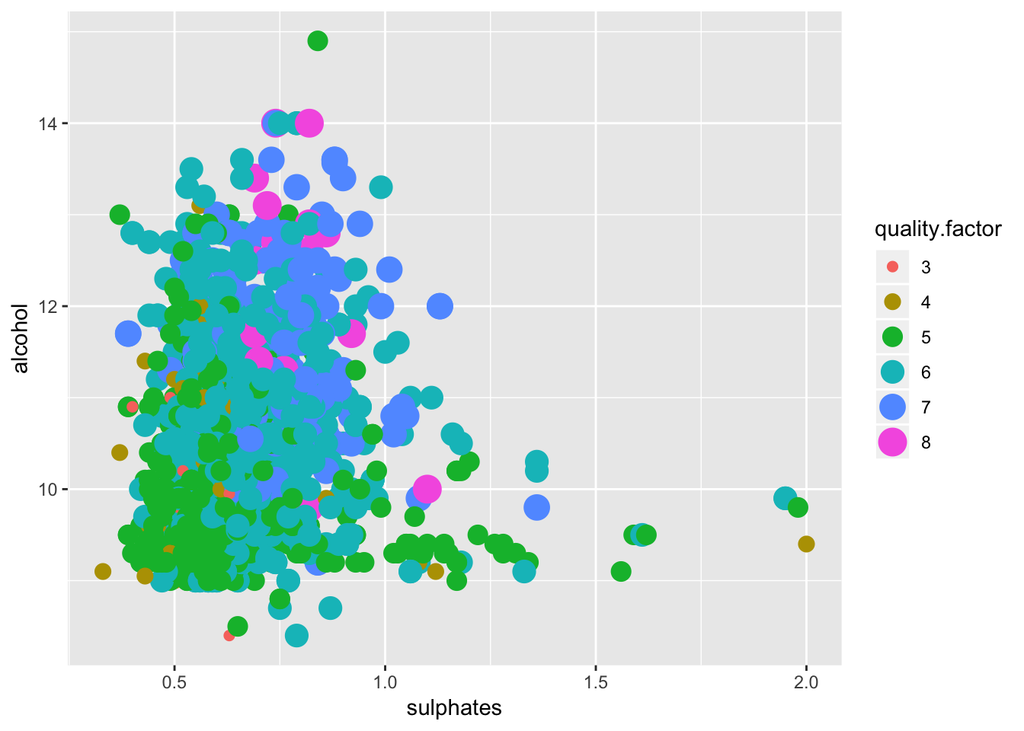

The following is a perfect one from the internet. But i’m not conviced.

But i don’t understand why do we transform ( take log10) of the data. By doing this, we are changing the actual value of the data provided. Why do we have to make the data normally distributed instead skewed.

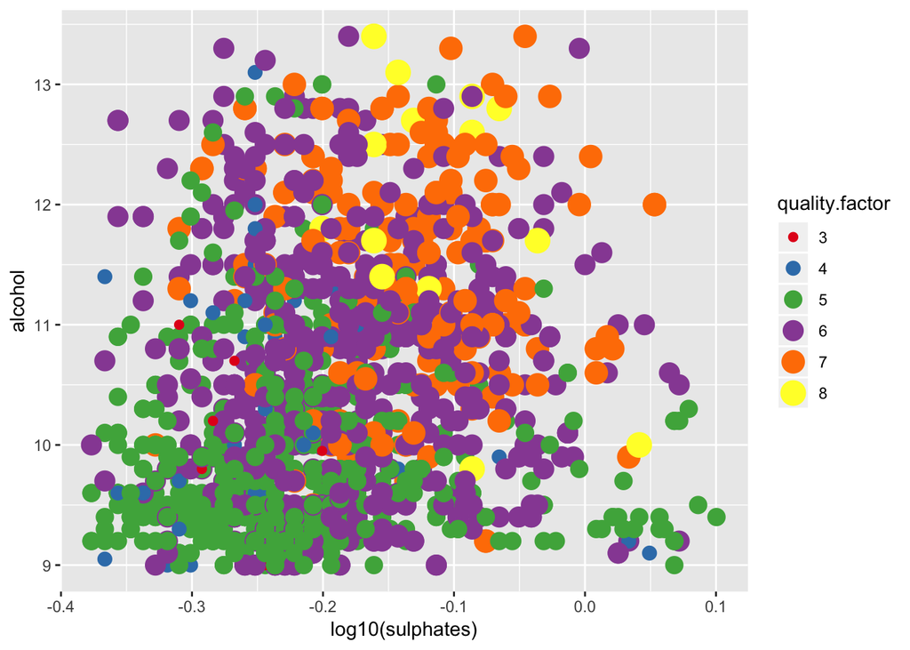

# Multivariate Analysis

### Talk about some of the relationships you observed in this part of the investigation. Were there features that strengthened each other in terms of looking at your feature(s) of interest?

From above multivariate plot, we can observe an increase in quality of red wine with the increase of both alcohol and sulphates.

### Were there any interesting or surprising interactions between features?

### OPTIONAL: Did you create any models with your dataset? Discuss the strengths and limitations of your model.

# Final Plots and Summary

> **Tip**: You’ve done a lot of exploration and have built up an understanding of the structure of and relationships between the variables in your dataset. Here, you will select three plots from all of your previous exploration to present here as a summary of some of your most interesting findings. Make sure that you have refined your selected plots for good titling, axis labels (with units), and good aesthetic choices (e.g. color, transparency). After each plot, make sure you justify why you chose each plot by describing what it shows.

### Plot One

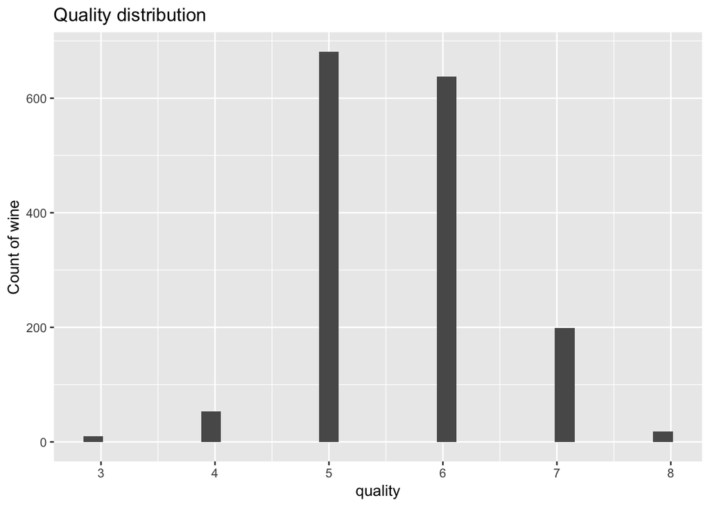

### Description One

From the above , we can see that the quality of the wine varies from 3 to 8. The mean of all red wine records is 5.6. Most the the red wine records categorized as 5 and 6.

### Plot Two

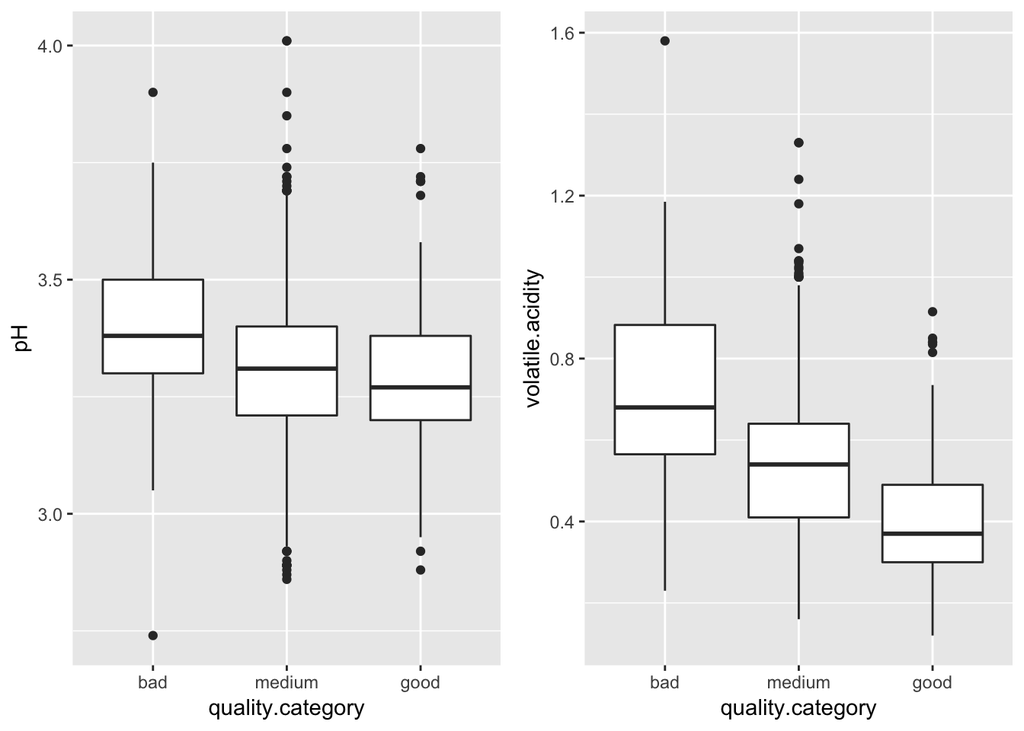

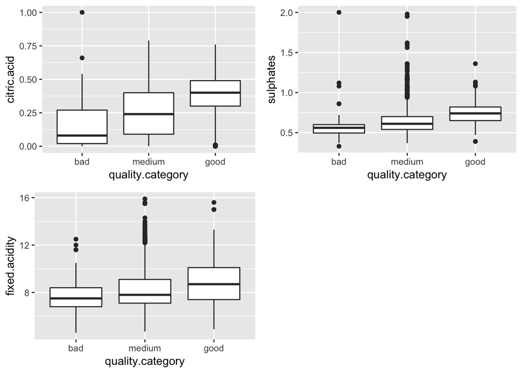

### Plot Three

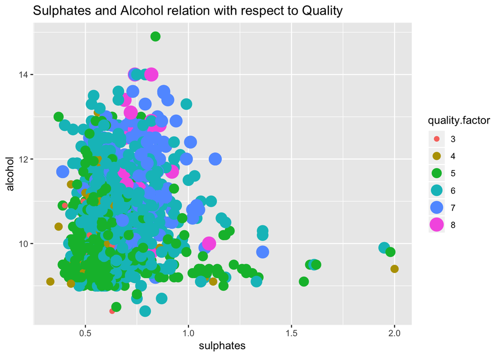

### Description Three

This shows the relation between alcohol, sulphates and the quality of red wine. We can notice that an increase in both variables affects the quality of alcohol.

# Reflection

The challenges in this data set is that there is no definit variable that affects the quality of the wine massively. There are many non-strong correlations between variables and it was superising that sugar has almost no affect on quality evern though it makes drinks tastes good. Another challenge, wine is prohibited in our religion. Hence, it is more difficult to invistigate on something we are not familiar with. It would be easier if we understand and know the nature behind the thing we are experimenting.